# Fifty States Project

7/10/2022

## Data Source and Procedures

### Open Source Software & Publicly Available Data

- GSOM (Global Summary of Monthly Data)
- Analysis and Graphics R/Rstudio
- Selected Station with longest records and fewest missing data
- Select month had strongest trend
- Evaluate Monthly Temp. Max and Min for trends

## Weather Station Selected

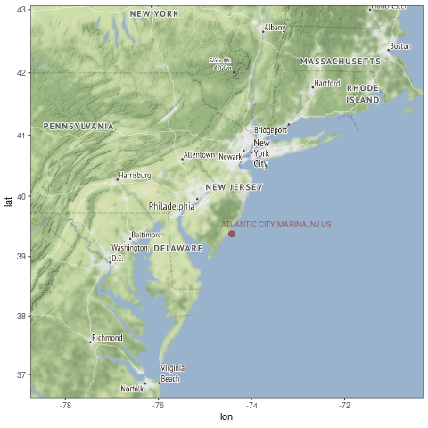

## Months with Largest Changes

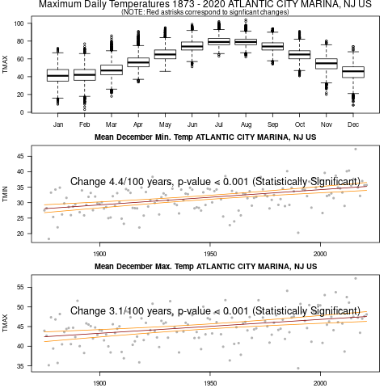

## Record Temperatures

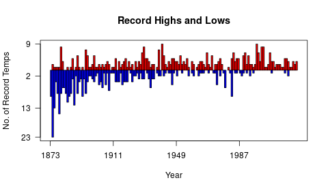

## Max. Temperature Anomaly Trend

[figure not shown]

## Impacts

- New Jersey’s climate is changing.
- The state has warmed by about three degrees (F) in the last century, heavy rainstorms are more frequent, and the sea is rising about one inch every six years.
- Higher water levels are eroding beaches, submerging low lands, exacerbating coastal flooding, and increasing the salinity of estuaries and aquifers.
- In the coming decades, changing the climate is likely to increase coastal and inland flooding, harm coastal and inland ecosystems, disrupt fishing and farming, and increase some risks to human health

[EPA Snapshot](https://19january2017snapshot.epa.gov/sites/production/files/2016-09/documents/climate-change-nj.pdf)

## State Adaptation / Mitigation Plans

- In 2009, during the administration of Governor Jon Corzine, the New Jersey Department of Environmental Protection (NJDEP) recommended that the state develop a statewide adaptation plan in a report titled, Meeting New Jersey’s 2020 Greenhouse Gas Limit: New Jersey’s Global Warming Response Act Recommendations Report.
- However, no formal plan was developed at that time and the Office of Climate Change and Energy within NJDEP was closed during the administration of Governor Chris Christie.

[Source: Georgetown Climate Center] (https://www.georgetownclimate.org/adaptation/state-information/new-jersey/overview.html)

## Next Steps

- Put ideas in comments how what other can do to support state efforts
- Be kind: Responding to climate change includes a complex array of ethical issues.
- “Be curious”, Ted Lasso.